# Synthesis exercise

Sergio Rodriguez Llana

6/6/2020

**GitHub respository:** https://github.com/SergioRLL/SRL_Omics_Techniques.git

## Description of the study:

**Title**: Expression data from livers of mice fed four different diets

**GEO identifier (GSE)**: GSE6297

**Organism**: *Mus musculus*

**Summary of the study**: This study tries to analyse the differences between human and apes diet and how it infuncies them beyond their DNA differences. The human diet diverges from those of other primates in various aspects, such as having a high calorie and protein content, as well as being cooked. For the study researchers used a laboratory mouse model to identify gene expression differences related to dietary differences.

**Experimental design**: Reseachers fed four groups of six genetically identical 8-week-old female NMR1 mice one of four diets:

- Chimpanzee: A diet consisting of vegetables, fruit and yogurt identical to the diet fed to chimpanzees in their ape facility.
- FastFood: A dient consisting exclusively of McDonalds (fast food).
- HumanCafe: A dient cosisting of cooked food eaten by the lab staff in the institute cafeteria.
- Pellet: A mouse pellet diet on which they were raised.

At the end of a 2-week period, mice were euthanized by cervical dislocation and both liver and brain tissue were dissected. RNA was extracted from the 24 liver and brain samples as per established lab protocols and processed in two batches (containing equal numbers of individuals from all groups).

```r
require(GEOquery)
gse <- getGEO("GSE6297")
```

```
## Found 1 file(s)
```

```
## GSE6297_series_matrix.txt.gz
```

```
## File stored at:
```

```
## /tmp/RtmpsqoipY/GPL1261.soft
```

```r
names(gse)
```

```
## [1] "GSE6297_series_matrix.txt.gz"
```

```r
gse[[1]]
```

```
## ExpressionSet (storageMode: lockedEnvironment)
## assayData: 45101 features, 24 samples
##   element names: exprs
## protocolData: none
## phenoData
##   sampleNames: GSM144707 GSM144708 ... GSM144730 (24 total)
##   varLabels: title geo_accession ... Strain:ch1 (40 total)
##   varMetadata: labelDescription
## featureData
##   featureNames: 1415670_at 1415671_at ... AFFX-TrpnX-M_at (45101 total)
##   fvarLabels: ID GB_ACC ... Gene Ontology Molecular Function (16 total)
##   fvarMetadata: Column Description labelDescription
## experimentData: use 'experimentData(object)'
##   pubMedIds: 18231591
## Annotation: GPL1261
```

```r
esetFromGEO <- gse[[1]]
```

## Description of the data:

The data of the study is displayed in a form of an Affymetrix Mouse Genome 430 2.0 Array.

The Expression Matrix looks as follows:

```r
require(Biobase)
head(exprs(esetFromGEO))
```

```
##              GSM144707 GSM144708 GSM144709 GSM144710 GSM144711 GSM144712
## 1415670_at    5.814663  6.181183  6.361403  5.027124  4.540326  5.194070
## 1415671_at    8.143719  8.285620  8.484633  7.642196  7.544798  7.883108
## 1415672_at    7.859979  7.729102  7.674707  7.148723  7.333418  7.753029
## 1415673_at    3.611563  3.691870  3.670835  3.868315  3.504496  3.817986
## 1415674_a_at  5.784022  5.854410  6.051814  5.103153  5.171708  5.623301
## 1415675_at    5.423964  5.474299  5.497647  4.691545  5.154246  4.791819
##              GSM144713 GSM144714 GSM144715 GSM144716 GSM144717 GSM144718
## 1415670_at    5.883083  6.010483  5.858698  5.321736  4.549718  5.268545
## 1415671_at    8.326789  8.114100  8.371491  8.204733  7.427503  8.096842
## 1415672_at    8.118769  8.094466  8.537736  8.095269  7.362172  8.124597
## 1415673_at    3.984547  3.668004  3.694028  3.714788  3.605294  3.677794
## 1415674_a_at  6.273496  6.192669  6.134427  5.665400  5.417380  5.692752
## 1415675_at    5.469426  5.482453  5.300695  4.932934  5.124335  5.095452
##              GSM144719 GSM144720 GSM144721 GSM144722 GSM144723 GSM144724
## 1415670_at    5.606858  5.921809  6.179215  5.277738  5.241534  4.508605
## 1415671_at    8.185594  8.251371  8.311479  8.103617  7.905654  7.423506
## 1415672_at    8.138181  8.152914  8.332296  7.752846  8.145574  7.254621
## 1415673_at    3.564698  3.660264  4.104580  3.579261  3.610670  3.537173
## 1415674_a_at  6.041425  6.110461  5.834398  5.885129  5.692189  5.176930
## 1415675_at    5.268749  5.542943  5.196933  5.540621  5.066987  4.901728
##              GSM144725 GSM144726 GSM144727 GSM144728 GSM144729 GSM144730
## 1415670_at    6.597141  6.149816  6.447506  5.836999  5.942128  6.129787
## 1415671_at    8.416838  8.373681  8.441509  8.067599  8.059431  8.197599
## 1415672_at    8.446769  8.079952  8.212412  7.814250  7.858588  8.216935
## 1415673_at    4.188005  3.760504  4.054429  3.761913  3.746422  3.912751
## 1415674_a_at  6.599257  6.315471  6.249057  5.773049  6.072727  6.282062
## 1415675_at    5.294333  5.387153  5.547483  5.338097  5.316445  5.126147
```

```r
dim(exprs(esetFromGEO))
```

```
## [1] 45101    24
```

It has 45101 rows corresponding to the genes and 24 columns that correspond to the biological samples used in the experiment.

```r
summary(exprs(esetFromGEO))
```

```
##    GSM144707        GSM144708        GSM144709        GSM144710
##  Min.   : 2.034   Min.   : 2.044   Min.   : 2.020   Min.   : 1.951
##  1st Qu.: 2.725   1st Qu.: 2.735   1st Qu.: 2.718   1st Qu.: 2.790
##  Median : 3.115   Median : 3.128   Median : 3.107   Median : 3.227
##  Mean   : 3.834   Mean   : 3.834   Mean   : 3.841   Mean   : 3.773
##  3rd Qu.: 4.254   3rd Qu.: 4.244   3rd Qu.: 4.257   3rd Qu.: 4.110
##  Max.   :12.900   Max.   :12.790   Max.   :12.992   Max.   :12.894
##    GSM144711        GSM144712        GSM144713        GSM144714
##  Min.   : 1.900   Min.   : 2.017   Min.   : 2.040   Min.   : 2.060
##  1st Qu.: 2.776   1st Qu.: 2.758   1st Qu.: 2.709   1st Qu.: 2.732
##  Median : 3.204   Median : 3.164   Median : 3.095   Median : 3.115
##  Mean   : 3.769   Mean   : 3.789   Mean   : 3.837   Mean   : 3.835
##  3rd Qu.: 4.118   3rd Qu.: 4.153   3rd Qu.: 4.282   3rd Qu.: 4.260
##  Max.   :12.982   Max.   :12.845   Max.   :12.730   Max.   :12.766
##    GSM144715        GSM144716        GSM144717        GSM144718
##  Min.   : 2.031   Min.   : 1.984   Min.   : 1.978   Min.   : 1.989
##  1st Qu.: 2.691   1st Qu.: 2.751   1st Qu.: 2.784   1st Qu.: 2.754
##  Median : 3.077   Median : 3.156   Median : 3.215   Median : 3.162
##  Mean   : 3.853   Mean   : 3.811   Mean   : 3.765   Mean   : 3.806
##  3rd Qu.: 4.316   3rd Qu.: 4.137   3rd Qu.: 4.127   3rd Qu.: 4.150
##  Max.   :12.897   Max.   :12.894   Max.   :12.713   Max.   :12.918
##    GSM144719        GSM144720        GSM144721        GSM144722
##  Min.   : 2.055   Min.   : 2.006   Min.   : 2.044   Min.   : 2.116
##  1st Qu.: 2.733   1st Qu.: 2.715   1st Qu.: 2.711   1st Qu.: 2.756
##  Median : 3.113   Median : 3.104   Median : 3.096   Median : 3.130
##  Mean   : 3.832   Mean   : 3.843   Mean   : 3.844   Mean   : 3.822
##  3rd Qu.: 4.231   3rd Qu.: 4.270   3rd Qu.: 4.249   3rd Qu.: 4.211
##  Max.   :12.772   Max.   :12.875   Max.   :13.011   Max.   :12.853
##    GSM144723        GSM144724        GSM144725        GSM144726
##  Min.   : 2.026   Min.   : 1.924   Min.   : 1.998   Min.   : 2.018
##  1st Qu.: 2.773   1st Qu.: 2.804   1st Qu.: 2.696   1st Qu.: 2.729
##  Median : 3.183   Median : 3.244   Median : 3.078   Median : 3.122
##  Mean   : 3.800   Mean   : 3.765   Mean   : 3.857   Mean   : 3.830
##  3rd Qu.: 4.120   3rd Qu.: 4.121   3rd Qu.: 4.333   3rd Qu.: 4.246
##  Max.   :12.885   Max.   :12.977   Max.   :12.887   Max.   :12.711
##    GSM144727        GSM144728        GSM144729        GSM144730
##  Min.   : 2.029   Min.   : 2.001   Min.   : 1.980   Min.   : 2.038
##  1st Qu.: 2.709   1st Qu.: 2.767   1st Qu.: 2.777   1st Qu.: 2.767
##  Median : 3.096   Median : 3.178   Median : 3.195   Median : 3.172
##  Mean   : 3.841   Mean   : 3.791   Mean   : 3.794   Mean   : 3.812
##  3rd Qu.: 4.289   3rd Qu.: 4.148   3rd Qu.: 4.150   3rd Qu.: 4.135
##  Max.   :12.782   Max.   :12.822   Max.   :12.769   Max.   :12.856
```

### PhenoData analysis:

```r
head(pData(esetFromGEO))
```

```
##                                                      title geo_accession
## GSM144707 Mouse_Liver_ChimpanzeeDiet__Batch_1__replicate_1     GSM144707
## GSM144708 Mouse_Liver_ChimpanzeeDiet__Batch_1__replicate_2     GSM144708
## GSM144709 Mouse_Liver_ChimpanzeeDiet__Batch_1__replicate_3     GSM144709
## GSM144710 Mouse_Liver_ChimpanzeeDiet__Batch_2__replicate_1     GSM144710
## GSM144711 Mouse_Liver_ChimpanzeeDiet__Batch_2__replicate_2     GSM144711
## GSM144712 Mouse_Liver_ChimpanzeeDiet__Batch_2__replicate_3     GSM144712
##                          status submission_date last_update_date type
## GSM144707 Public on Jan 15 2008     Nov 16 2006      Aug 28 2018  RNA
## GSM144708 Public on Jan 15 2008     Nov 16 2006      Aug 28 2018  RNA
## GSM144709 Public on Jan 15 2008     Nov 16 2006      Aug 28 2018  RNA
## GSM144710 Public on Jan 15 2008     Nov 16 2006      Aug 28 2018  RNA
## GSM144711 Public on Jan 15 2008     Nov 16 2006      Aug 28 2018  RNA
## GSM144712 Public on Jan 15 2008     Nov 16 2006      Aug 28 2018  RNA
##           channel_count       source_name_ch1 organism_ch1 characteristics_ch1
## GSM144707             1 Dissected Mouse Liver Mus musculus      Strain: NMR-1.
## GSM144708             1 Dissected Mouse Liver Mus musculus      Strain: NMR-1.
## GSM144709             1 Dissected Mouse Liver Mus musculus      Strain: NMR-1.
## GSM144710             1 Dissected Mouse Liver Mus musculus      Strain: NMR-1.
## GSM144711             1 Dissected Mouse Liver Mus musculus      Strain: NMR-1.
## GSM144712             1 Dissected Mouse Liver Mus musculus      Strain: NMR-1.
##           characteristics_ch1.1                 characteristics_ch1.2
## GSM144707       Gender: Female. Age: 8 weeks at the experiment start.
## GSM144708       Gender: Female. Age: 8 weeks at the experiment start.
## GSM144709       Gender: Female. Age: 8 weeks at the experiment start.
## GSM144710       Gender: Female. Age: 8 weeks at the experiment start.
## GSM144711       Gender: Female. Age: 8 weeks at the experiment start.
## GSM144712       Gender: Female. Age: 8 weeks at the experiment start.
##                                                                                                                                                                                                                                                                              treatment_protocol_ch1
## GSM144707 Mice were euthanized by cervical dislocation and liver tissue was dissected. RNA was extracted from the 24 samples as per established lab protocols (Franz et al, 2005, PMID: 16420671) and processed in two batches (containing equal numbers of individuals from all treatment groups).
## GSM144708 Mice were euthanized by cervical dislocation and liver tissue was dissected. RNA was extracted from the 24 samples as per established lab protocols (Franz et al, 2005, PMID: 16420671) and processed in two batches (containing equal numbers of individuals from all treatment groups).
## GSM144709 Mice were euthanized by cervical dislocation and liver tissue was dissected. RNA was extracted from the 24 samples as per established lab protocols (Franz et al, 2005, PMID: 16420671) and processed in two batches (containing equal numbers of individuals from all treatment groups).
## GSM144710 Mice were euthanized by cervical dislocation and liver tissue was dissected. RNA was extracted from the 24 samples as per established lab protocols (Franz et al, 2005, PMID: 16420671) and processed in two batches (containing equal numbers of individuals from all treatment groups).
## GSM144711 Mice were euthanized by cervical dislocation and liver tissue was dissected. RNA was extracted from the 24 samples as per established lab protocols (Franz et al, 2005, PMID: 16420671) and processed in two batches (containing equal numbers of individuals from all treatment groups).
## GSM144712 Mice were euthanized by cervical dislocation and liver tissue was dissected. RNA was extracted from the 24 samples as per established lab protocols (Franz et al, 2005, PMID: 16420671) and processed in two batches (containing equal numbers of individuals from all treatment groups).
##                                                 growth_protocol_ch1
## GSM144707 Laboratory mice were fed a Chimpanzee diet for two weeks.
## GSM144708 Laboratory mice were fed a Chimpanzee diet for two weeks.
## GSM144709 Laboratory mice were fed a Chimpanzee diet for two weeks.
## GSM144710 Laboratory mice were fed a Chimpanzee diet for two weeks.
```

[output cut: 99 more lines]

```
## GSM144712 ftp://ftp.ncbi.nlm.nih.gov/geo/samples/GSM144nnn/GSM144712/suppl/GSM144712.CEL.gz
##           data_row_count                 relation
## GSM144707          45101 Reanalyzed by: GSE119085
## GSM144708          45101 Reanalyzed by: GSE119085
## GSM144709          45101 Reanalyzed by: GSE119085
## GSM144710          45101 Reanalyzed by: GSE119085
## GSM144711          45101 Reanalyzed by: GSE119085
## GSM144712          45101 Reanalyzed by: GSE119085
##                                    Age:ch1 Gender:ch1 Strain:ch1
## GSM144707 8 weeks at the experiment start.    Female.     NMR-1.
## GSM144708 8 weeks at the experiment start.    Female.     NMR-1.
## GSM144709 8 weeks at the experiment start.    Female.     NMR-1.
## GSM144710 8 weeks at the experiment start.    Female.     NMR-1.
## GSM144711 8 weeks at the experiment start.    Female.     NMR-1.
## GSM144712 8 weeks at the experiment start.    Female.     NMR-1.
```

```r
ph_data <- pData(esetFromGEO)
colnames(pData(esetFromGEO))
```

```
##  [1] "title"                   "geo_accession"
##  [3] "status"                  "submission_date"
##  [5] "last_update_date"        "type"
##  [7] "channel_count"           "source_name_ch1"
##  [9] "organism_ch1"            "characteristics_ch1"
## [11] "characteristics_ch1.1"   "characteristics_ch1.2"
## [13] "treatment_protocol_ch1"  "growth_protocol_ch1"
## [15] "molecule_ch1"            "extract_protocol_ch1"
## [17] "label_ch1"               "label_protocol_ch1"
## [19] "taxid_ch1"               "hyb_protocol"
## [21] "scan_protocol"           "description"
## [23] "data_processing"         "platform_id"
## [25] "contact_name"            "contact_email"
## [27] "contact_phone"           "contact_fax"
## [29] "contact_department"      "contact_institute"
## [31] "contact_address"         "contact_city"
## [33] "contact_zip/postal_code" "contact_country"
## [35] "supplementary_file"      "data_row_count"
## [37] "relation"                "Age:ch1"
## [39] "Gender:ch1"              "Strain:ch1"
```

```r
ph_data$title
```

```
##  [1] "Mouse_Liver_ChimpanzeeDiet__Batch_1__replicate_1"
##  [2] "Mouse_Liver_ChimpanzeeDiet__Batch_1__replicate_2"
##  [3] "Mouse_Liver_ChimpanzeeDiet__Batch_1__replicate_3"
##  [4] "Mouse_Liver_ChimpanzeeDiet__Batch_2__replicate_1"
##  [5] "Mouse_Liver_ChimpanzeeDiet__Batch_2__replicate_2"
##  [6] "Mouse_Liver_ChimpanzeeDiet__Batch_2__replicate_3"
##  [7] "Mouse_Liver_FastFoodDiet__Batch_1__replicate_1"
##  [8] "Mouse_Liver_FastFoodDiet__Batch_1__replicate_2"
##  [9] "Mouse_Liver_FastFoodDiet__Batch_1__replicate_3"
## [10] "Mouse_Liver_FastFoodDiet__Batch_2__replicate_1"
## [11] "Mouse_Liver_FastFoodDiet__Batch_2__replicate_2"
## [12] "Mouse_Liver_FastFoodDiet__Batch_2__replicate_3"
## [13] "Mouse_Liver_HumanCafeDiet__Batch_1__replicate_1"
## [14] "Mouse_Liver_HumanCafeDiet__Batch_1__replicate_2"
## [15] "Mouse_Liver_HumanCafeDiet__Batch_1__replicate_3"
## [16] "Mouse_Liver_HumanCafeDiet__Batch_2__replicate_1"
## [17] "Mouse_Liver_HumanCafeDiet__Batch_2__replicate_2"
## [18] "Mouse_Liver_HumanCafeDiet__Batch_2__replicate_3"
## [19] "Mouse_Liver_PelletDiet__Batch_1__replicate_1"
## [20] "Mouse_Liver_PelletDiet__Batch_1__replicate_2"
## [21] "Mouse_Liver_PelletDiet__Batch_1__replicate_3"
## [22] "Mouse_Liver_PelletDiet__Batch_2__replicate_1"
## [23] "Mouse_Liver_PelletDiet__Batch_2__replicate_2"
## [24] "Mouse_Liver_PelletDiet__Batch_2__replicate_3"
```

In the previous table we can see that the samples come form *Mus musculus*, from the titles we can see the different factors and goups which are discussed in the next section. Se can see that the response was quantified with RNA. There is also the information regarding the mouse strain, gender and age already described in the Experimental design above. It is described the treatment protocol (how the samples were obtained), the diet followed in each sample, etc. Other information like the label and hybridation protocols are also indicated.

### Plots:

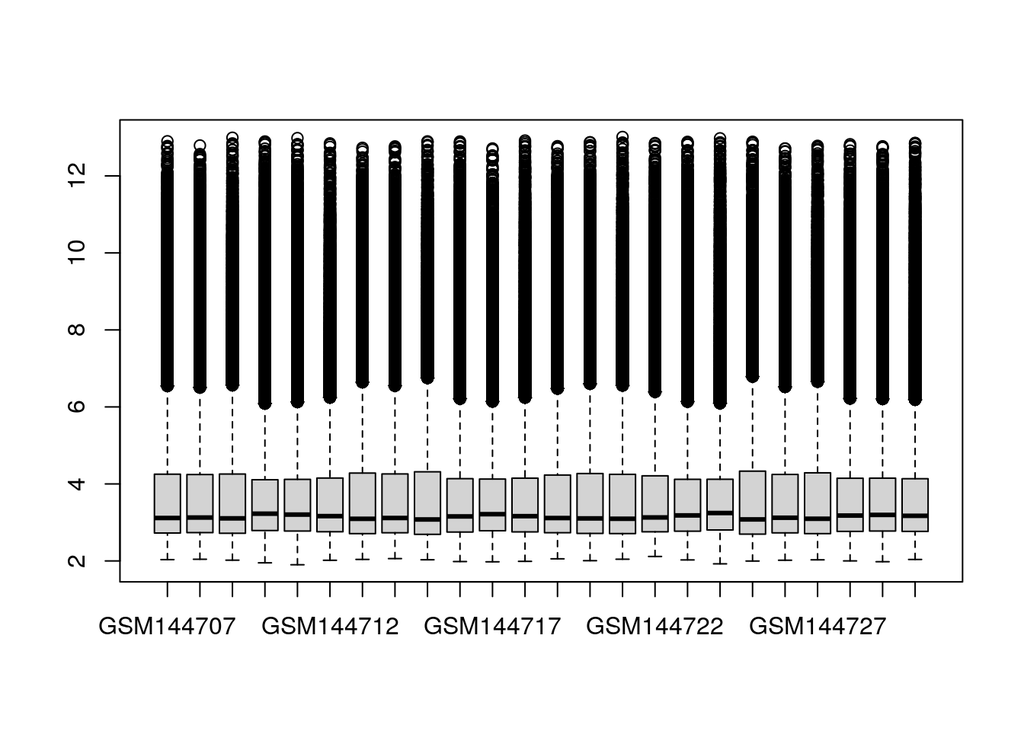

```r
boxplot(exprs(esetFromGEO))
```

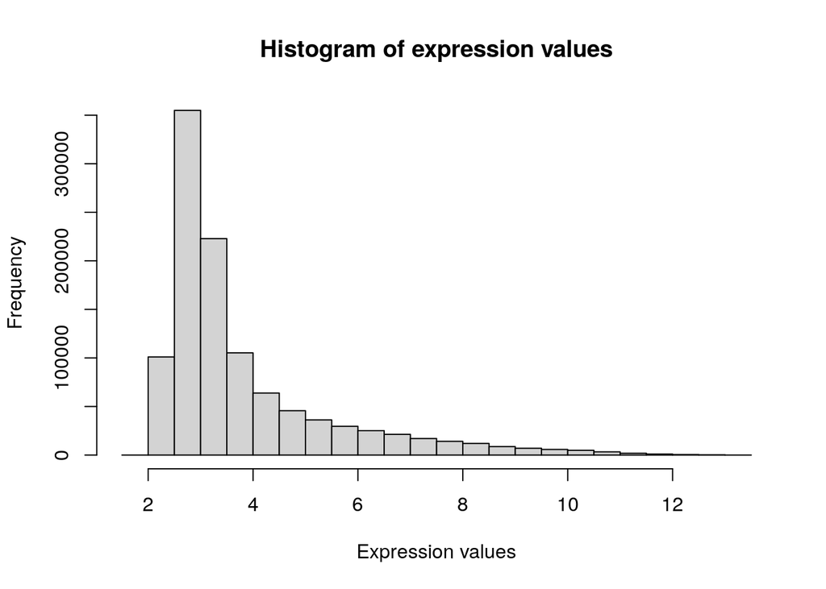

```r
hist(exprs(esetFromGEO), main = "Histogram of expression values", xlab = "Expression values")
```

From these plots it is observed that the great majority of the data (>50%) is between 2 and 4, and that there are some outlier values, present in every sample that are higher and go far away from the sample mean and median.

## Experimental design

**Response variable**: gene expression

**Sources of variation**:

- **Treatment**: Diets: Chimpanzee, FastFood, HuamanCafe and Pellet.
- **Groups**: Batch (2 fro every diet type).

Number of experimental units per each combiantion of factors: 3

**Sample size**: 24 samples

**Experimental design**: Factorial Design (all the mouse individuals were genetically equal: 8-week-old female NMR1 mice).

## Comparisons

I think that, for the sake of the experiment, some reasonable comparisons that it could be interesing to observe are the ones between human food (including FastFood and HumanCafe diets), mouse food (Pellet diet) and the one corresponding to chipanzee.

This could be interesting to observe the differences that the experiment aims between human and apes but also it may be interesing to observe the effect of this diets in mice and how are affeccting them.

The comparisons to be performed are:

To evaulate the differences between chimpanzee and human-type diets:

- Chimp-FF
- Chimp-HC

To evaulate the effect that human and chimpanzee diets ecert in mice compared to a common diet for them:

- P-FF
- P-HC
- P-Chimp

## Design Matrix

```r
myValues <- c(c(1,1,1,0,0,0,0,0,0,0,0,0,0,0,0,0,0,0,0,0,0,0,0,0),
              c(0,0,0,1,1,1,0,0,0,0,0,0,0,0,0,0,0,0,0,0,0,0,0,0),
              c(0,0,0,0,0,0,1,1,1,0,0,0,0,0,0,0,0,0,0,0,0,0,0,0),
              c(0,0,0,0,0,0,0,0,0,1,1,1,0,0,0,0,0,0,0,0,0,0,0,0),
              c(0,0,0,0,0,0,0,0,0,0,0,0,1,1,1,0,0,0,0,0,0,0,0,0),
              c(0,0,0,0,0,0,0,0,0,0,0,0,0,0,0,1,1,1,0,0,0,0,0,0),
              c(0,0,0,0,0,0,0,0,0,0,0,0,0,0,0,0,0,0,1,1,1,0,0,0),
              c(0,0,0,0,0,0,0,0,0,0,0,0,0,0,0,0,0,0,0,0,0,1,1,1))
myMatrix <- matrix(myValues, ncol=8, byrow=F)
colnames(myMatrix) <- c("Chimp_B1", "Chimp_B2", "FF_B1", "FF_B2", "HC_B1", "HC_B2", "P_B1", "P_B2")
rownames(myMatrix) <- paste("sample",
                             c(paste("Chimp","B1",1:3, sep="_"),
                               paste("Chimp","B2",1:3, sep="_"),
                               paste("FF","B1",1:3, sep="_"),
                               paste("FF","B2",1:3, sep="_"),
                               paste("HC","B1",1:3, sep="_"),
                               paste("HC","B2",1:3, sep="_"),
                               paste("P","B1",1:3, sep="_"),
                               paste("P","B2",1:3, sep="_")),sep=".")
myMatrix
```

```
##                   Chimp_B1 Chimp_B2 FF_B1 FF_B2 HC_B1 HC_B2 P_B1 P_B2
## sample.Chimp_B1_1        1        0     0     0     0     0    0    0
## sample.Chimp_B1_2        1        0     0     0     0     0    0    0
## sample.Chimp_B1_3        1        0     0     0     0     0    0    0
## sample.Chimp_B2_1        0        1     0     0     0     0    0    0
## sample.Chimp_B2_2        0        1     0     0     0     0    0    0
## sample.Chimp_B2_3        0        1     0     0     0     0    0    0
## sample.FF_B1_1           0        0     1     0     0     0    0    0
## sample.FF_B1_2           0        0     1     0     0     0    0    0
## sample.FF_B1_3           0        0     1     0     0     0    0    0
## sample.FF_B2_1           0        0     0     1     0     0    0    0
## sample.FF_B2_2           0        0     0     1     0     0    0    0
## sample.FF_B2_3           0        0     0     1     0     0    0    0
## sample.HC_B1_1           0        0     0     0     1     0    0    0
## sample.HC_B1_2           0        0     0     0     1     0    0    0
## sample.HC_B1_3           0        0     0     0     1     0    0    0
## sample.HC_B2_1           0        0     0     0     0     1    0    0
## sample.HC_B2_2           0        0     0     0     0     1    0    0
## sample.HC_B2_3           0        0     0     0     0     1    0    0
## sample.P_B1_1            0        0     0     0     0     0    1    0
## sample.P_B1_2            0        0     0     0     0     0    1    0
## sample.P_B1_3            0        0     0     0     0     0    1    0
## sample.P_B2_1            0        0     0     0     0     0    0    1
## sample.P_B2_2            0        0     0     0     0     0    0    1
## sample.P_B2_3            0        0     0     0     0     0    0    1
```

## Contrast Matrix

**NOTE**: In order to make the comparisons analysis simpler I am going to do the comparisons within samples of the same Batch (B1, B2).

```r
library(limma)
contMat <- makeContrasts(Chimp_FF_B1=Chimp_B1-FF_B1,
                       Chimp_FF_B2=Chimp_B2-FF_B2,
                       Chimp_HC_B1=Chimp_B1-HC_B1,
                       Chimp_HC_B2=Chimp_B2-HC_B2,
                       P_FF_B1=P_B1-FF_B1,
                       P_FF_B2=P_B2-FF_B2,
                       P_HC_B1=P_B1-HC_B1,
                       P_HC_B2=P_B2-HC_B2,
                       P_Chimp_B1=P_B1-Chimp_B1,
                       P_Chimp_B2=P_B2-Chimp_B2,
                       levels=myMatrix)
contMat
```

```
##           Contrasts
## Levels     Chimp_FF_B1 Chimp_FF_B2 Chimp_HC_B1 Chimp_HC_B2 P_FF_B1 P_FF_B2
##   Chimp_B1           1           0           1           0       0       0
##   Chimp_B2           0           1           0           1       0       0
##   FF_B1             -1           0           0           0      -1       0
##   FF_B2              0          -1           0           0       0      -1
##   HC_B1              0           0          -1           0       0       0
##   HC_B2              0           0           0          -1       0       0
##   P_B1               0           0           0           0       1       0
##   P_B2               0           0           0           0       0       1
##           Contrasts
## Levels     P_HC_B1 P_HC_B2 P_Chimp_B1 P_Chimp_B2
##   Chimp_B1       0       0         -1          0
##   Chimp_B2       0       0          0         -1
##   FF_B1          0       0          0          0
##   FF_B2          0       0          0          0
##   HC_B1         -1       0          0          0
##   HC_B2          0      -1          0          0
##   P_B1           1       0          1          0
##   P_B2           0       1          0          1
```

## Fitting a linear model, estimating the contrasts and generating a “topTable” and a “volcanoPlot”

```r
require(limma)
dataMatrix <- exprs(esetFromGEO)
fit<-lmFit(dataMatrix, myMatrix)
fit.main<-contrasts.fit(fit, contMat)
fit.main<-eBayes(fit.main)
```

```r
topTab_Chimp_FF_B1 <- topTable (fit.main, number=nrow(fit.main), coef="Chimp_FF_B1", adjust="fdr"); head(topTab_Chimp_FF_B1)
```

```
##                   logFC  AveExpr         t      P.Value  adj.P.Val        B
## 1437085_at   -1.1171149 4.832223 -6.728390 1.990620e-06 0.04388029 4.324010
## 1425645_s_at -2.3867057 6.260131 -6.572337 2.735320e-06 0.04388029 4.083266
## 1435452_at    1.5757507 4.559217  6.408108 3.835136e-06 0.04388029 3.825208
## 1449164_at   -0.9327099 3.905576 -6.377482 4.086224e-06 0.04388029 3.776554
## 1444506_at    0.5723675 3.042386  6.272922 5.078727e-06 0.04388029 3.609190
## 1428698_at    0.5187242 5.400481  5.938969 1.026737e-05 0.04388029 3.061806
```

```r
topTab_Chimp_FF_B2 <- topTable (fit.main, number=nrow(fit.main), coef="Chimp_FF_B2", adjust="fdr"); head(topTab_Chimp_FF_B2)
```

```
##                   logFC  AveExpr         t      P.Value   adj.P.Val        B
## 1423257_at   -4.4181841 6.823271 -9.069769 2.498329e-08 0.001126771 6.762184
## 1418238_at   -0.8313464 8.296246 -7.367155 5.609139e-07 0.012648889 4.802495
## 1416833_at   -2.4088314 8.244446 -6.102648 7.258641e-06 0.081916686 3.021015
## 1448382_at   -1.2800719 9.520413 -5.864528 1.203468e-05 0.081916686 2.653196
## 1425645_s_at -2.1190106 6.260131 -5.835178 1.281479e-05 0.081916686 2.607164
## 1416197_at   -0.4487997 6.925433 -5.816329 1.334296e-05 0.081916686 2.577523
```

```r
topTab_Chimp_HC_B1 <- topTable (fit.main, number=nrow(fit.main), coef="Chimp_HC_B1", adjust="fdr"); head(topTab_Chimp_HC_B1)
```

```
##                   logFC  AveExpr         t      P.Value   adj.P.Val        B
## 1425645_s_at -2.9501916 6.260131 -8.124024 1.342652e-07 0.006055494 5.593156
## 1422257_s_at -2.6942109 5.195867 -7.502447 4.319753e-07 0.009741258 4.854292
## 1419146_a_at  2.8496116 6.435535  6.616489 2.499279e-06 0.031220935 3.683674
## 1451787_at   -2.5360805 6.032565 -6.566363 2.768979e-06 0.031220935 3.613192
## 1456694_x_at -0.3330846 5.559132 -6.314883 4.653544e-06 0.031432798 3.252665
## 1438377_x_at  0.7423435 4.452549  6.301473 4.785286e-06 0.031432798 3.233116
```

```r
topTab_Chimp_HC_B2 <- topTable (fit.main, number=nrow(fit.main), coef="Chimp_HC_B2", adjust="fdr"); head(topTab_Chimp_HC_B2)
```

```
##                   logFC   AveExpr         t      P.Value  adj.P.Val        B
## 1425150_at    1.2333380  6.682196  7.085194 9.744574e-07 0.02301891 4.296486
## 1418238_at   -0.7968814  8.296246 -7.061736 1.020772e-06 0.02301891 4.265703
## 1417709_at    1.1923157  7.996764  6.737646 1.953650e-06 0.02937052 3.830217
## 1425303_at    2.9731348  5.802444  6.330382 4.505924e-06 0.05080542 3.255831
## 1417580_s_at -0.9266367 10.088203 -5.997668 9.063185e-06 0.08175174 2.764171
## 1449001_at   -0.7199229  6.275785 -5.814528 1.339460e-05 0.08210896 2.485047
```

```r
topTab_P_FF_B1 <- topTable (fit.main, number=nrow(fit.main), coef="P_FF_B1", adjust="fdr"); head(topTab_P_FF_B1)
```

```
##                  logFC  AveExpr          t      P.Value    adj.P.Val         B
## 1423257_at   -5.884636 6.823271 -12.080143 2.345597e-10 9.494672e-06 11.910475
## 1417028_a_at  1.708875 3.980668  11.667532 4.210404e-10 9.494672e-06 11.506747
## 1438751_at    1.572876 3.291271  10.155969 4.142414e-09 6.227567e-05  9.852766
## 1459860_x_at  2.383989 3.468372   9.929910 5.953791e-09 6.713049e-05  9.579749
## 1417212_at   -1.148041 7.033555  -8.248185 1.069665e-07 8.606271e-04  7.312673
## 1415776_at   -1.212442 8.738465  -8.155996 1.266076e-07 8.606271e-04  7.175634
```

```r
topTab_P_FF_B2 <- topTable (fit.main, number=nrow(fit.main), coef="P_FF_B2", adjust="fdr"); head(topTab_P_FF_B2)
```

```
##                  logFC   AveExpr          t      P.Value    adj.P.Val         B
## 1423257_at   -6.447669  6.823271 -13.235951 4.934940e-11 2.225707e-06 12.127446
## 1416946_a_at -1.450679 10.318943 -10.376546 2.923493e-09 6.592622e-05  9.559575
## 1449442_at   -1.562802  7.545277  -9.511282 1.183606e-08 1.401673e-04  8.584810
## 1417203_at    1.952839  7.485185   9.481850 1.243141e-08 1.401673e-04  8.549780
## 1416947_s_at -1.118322 11.097282  -9.347592 1.557076e-08 1.404513e-04  8.388359
## 1415776_at   -1.351993  8.738465  -9.094743 2.393453e-08 1.799119e-04  8.077013
```

```r
topTab_P_HC_B1 <- topTable (fit.main, number=nrow(fit.main), coef="P_HC_B1", adjust="fdr"); head(topTab_P_HC_B1)
```

```
##                  logFC  AveExpr          t      P.Value    adj.P.Val         B
## 1423257_at   -5.692625 6.823271 -11.685976 4.100336e-10 1.295715e-05 12.023005
## 1417028_a_at  1.677411 3.980668  11.452709 5.745837e-10 1.295715e-05 11.768870
## 1438751_at    1.726138 3.291271  11.145568 9.032172e-10 1.357867e-05 11.424394
## 1459860_x_at  2.464274 3.468372  10.264317 3.488352e-09 3.933204e-05 10.370501
## 1417828_at    2.564216 8.476105   9.699942 8.662325e-09 7.813590e-05  9.641277
## 1453435_a_at -1.386014 5.035176  -8.844178 3.693170e-08 2.655709e-04  8.448406
```

```r
topTab_P_HC_B2 <- topTable (fit.main, number=nrow(fit.main), coef="P_HC_B2", adjust="fdr"); head(topTab_P_HC_B2)
```

```
##                  logFC  AveExpr         t      P.Value   adj.P.Val        B
## 1423257_at   -4.584503 6.823271 -9.411193 1.399164e-08 0.000631037 8.531862
## 1417203_at    1.744474 7.485185  8.470152 7.160406e-08 0.001614707 7.319734
## 1416933_at   -1.494284 9.574238 -7.956937 1.828914e-07 0.002732837 6.598946
## 1417168_a_at -2.491236 6.426355 -7.726263 2.819319e-07 0.002732837 6.260635
## 1416750_at    1.610919 7.753989  7.688268 3.029685e-07 0.002732837 6.204044
## 1427202_at   -1.984706 5.908737 -7.487991 4.441492e-07 0.003231581 5.901663
```

```r
topTab_P_Chimp_B1 <- topTable (fit.main, number=nrow(fit.main), coef="P_Chimp_B1", adjust="fdr"); head(topTab_P_Chimp_B1)
```

```
##                 logFC  AveExpr         t      P.Value    adj.P.Val         B
## 1417028_a_at 1.510227 3.980668 10.311239 3.239460e-09 6.081097e-05 10.732700
## 1416265_at   1.120858 4.817080 10.177080 4.005597e-09 6.081097e-05 10.555450
## 1459860_x_at 2.403489 3.468372 10.011129 5.222829e-09 6.081097e-05 10.332856
## 1421410_a_at 1.939712 3.775001  9.991170 5.393314e-09 6.081097e-05 10.305832
## 1417828_at   2.551392 8.476105  9.651433 9.382565e-09 7.553090e-05  9.837439
## 1426913_at   1.518903 3.606300  9.592568 1.034125e-08 7.553090e-05  9.754646
```

```r
topTab_P_Chimp_B2 <- topTable (fit.main, number=nrow(fit.main), coef="P_Chimp_B2", adjust="fdr"); head(topTab_P_Chimp_B2)
```

```
##                  logFC  AveExpr         t      P.Value    adj.P.Val        B
## 1417203_at    2.064174 7.485185 10.022427 5.128828e-09 0.0002004533 9.936704
## 1436590_at   -1.965634 8.422730 -9.684230 8.889086e-09 0.0002004533 9.502718
## 1425869_a_at  1.923725 8.624053  9.432690 1.349644e-08 0.0002029009 9.169356
## 1449442_at   -1.398415 7.545277 -8.510814 6.657393e-08 0.0007506377 7.866833
## 1416750_at    1.716874 7.753989  8.193952 1.181024e-07 0.0008941781 7.388629
## 1424140_at    1.202038 4.251963  8.190013 1.189568e-07 0.0008941781 7.382583
```

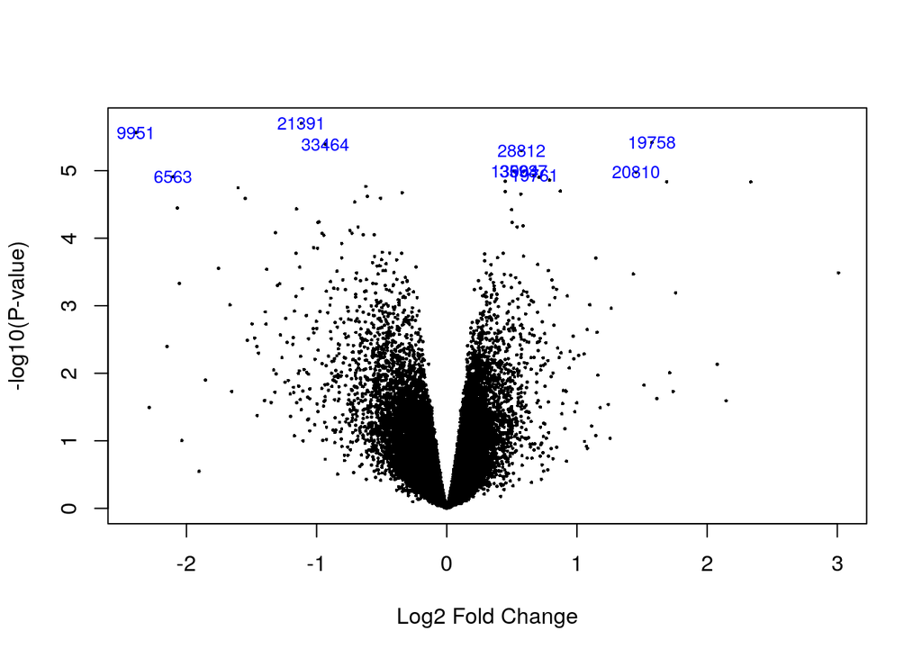

```r
volcanoplot(fit.main, coef="Chimp_FF_B1", highlight=10)
```

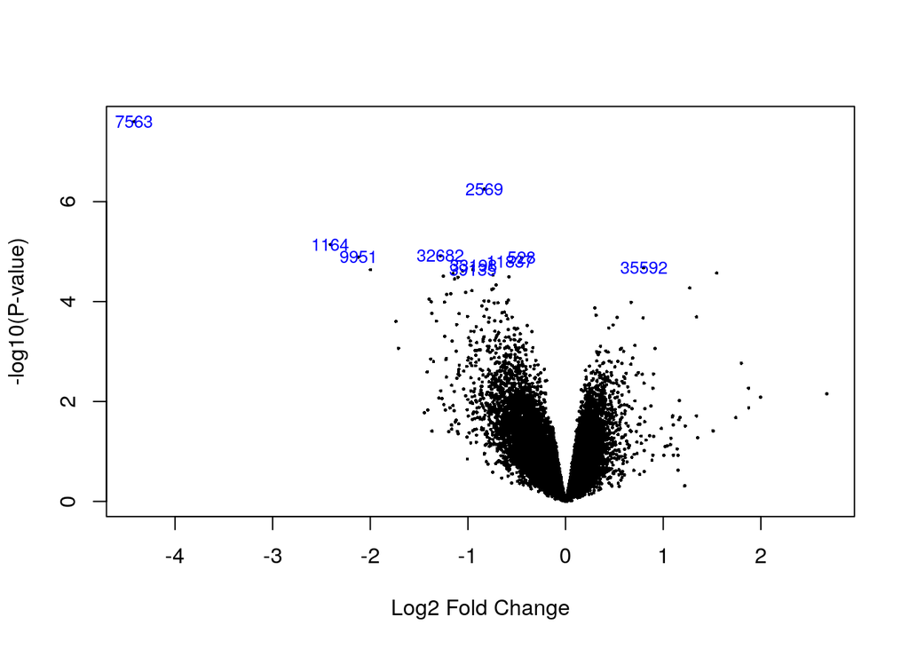

```r
volcanoplot(fit.main, coef="Chimp_FF_B2", highlight=10)
```

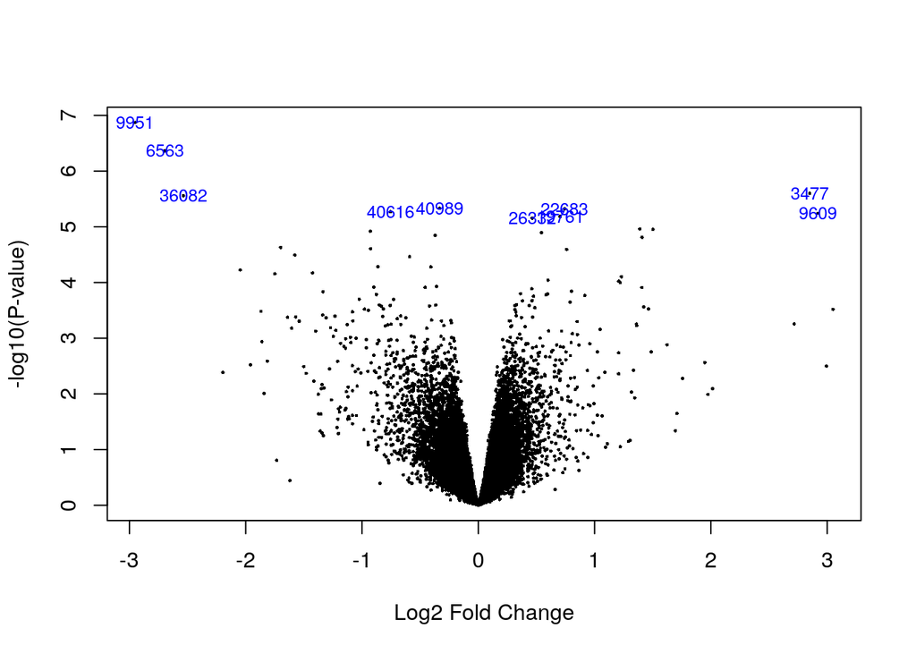

```r
volcanoplot(fit.main, coef="Chimp_HC_B1", highlight=10)
```

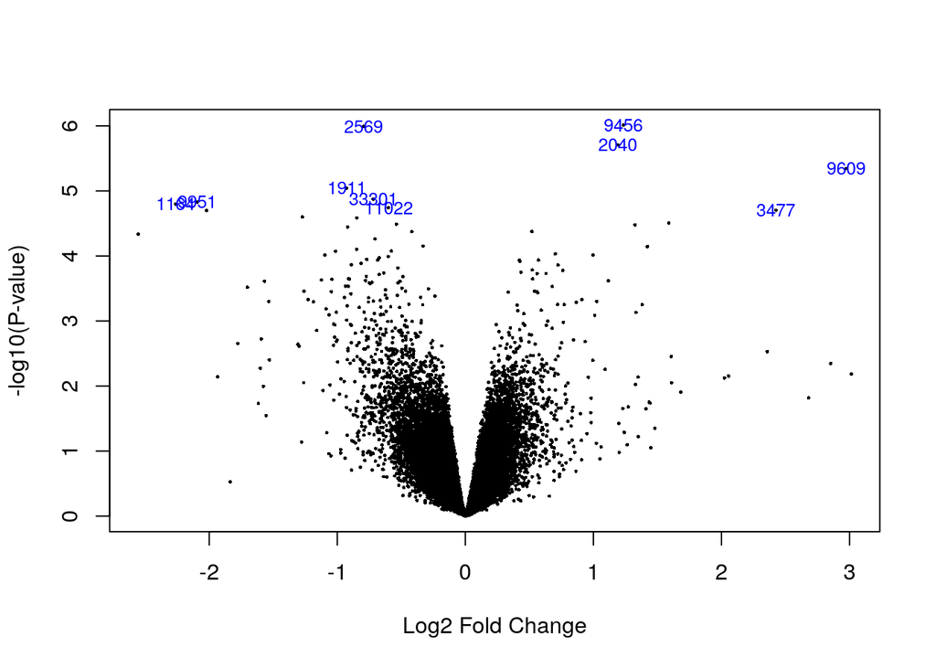

```r
volcanoplot(fit.main, coef="Chimp_HC_B2", highlight=10)
```

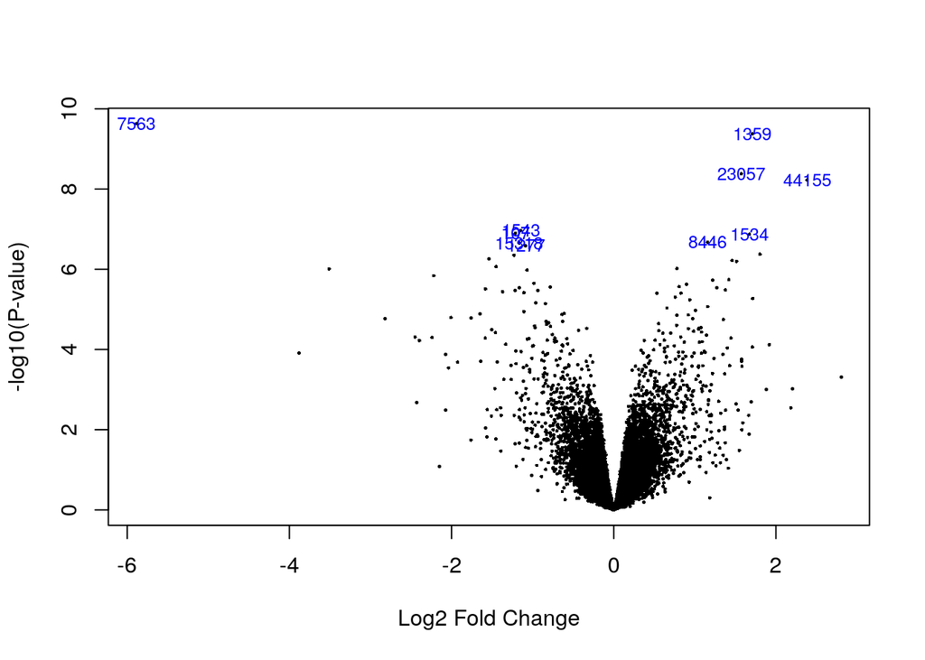

```r
volcanoplot(fit.main, coef="P_FF_B1", highlight=10)
```

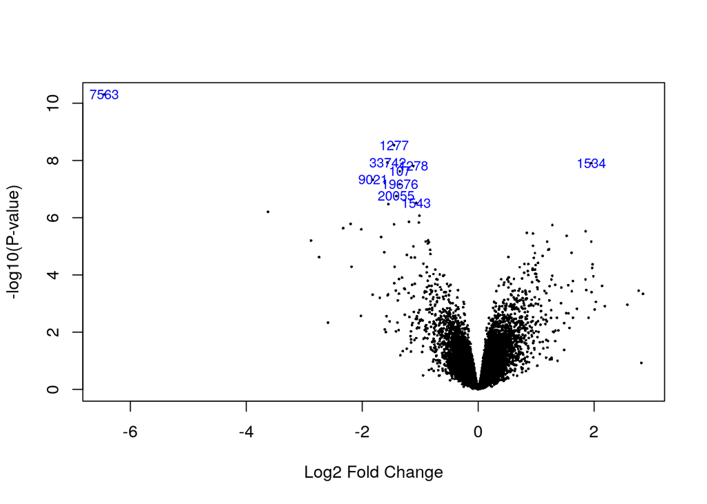

```r
volcanoplot(fit.main, coef="P_FF_B2", highlight=10)
```

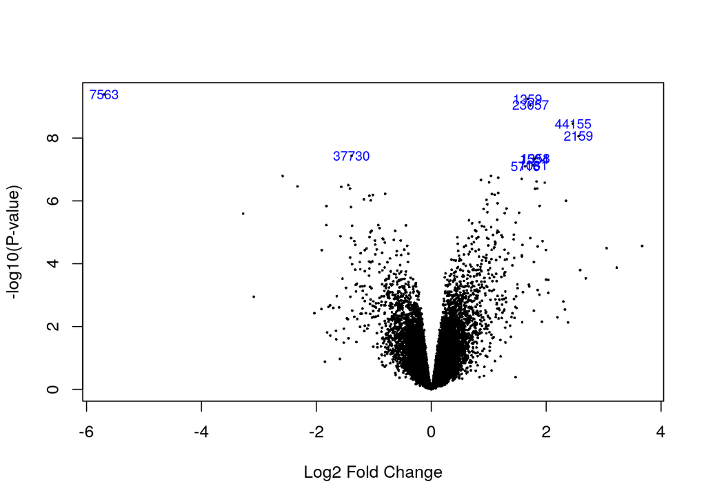

```r
volcanoplot(fit.main, coef="P_HC_B1", highlight=10)
```

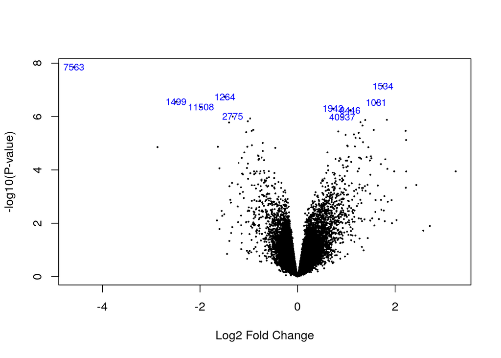

```r
volcanoplot(fit.main, coef="P_HC_B2", highlight=10)
```

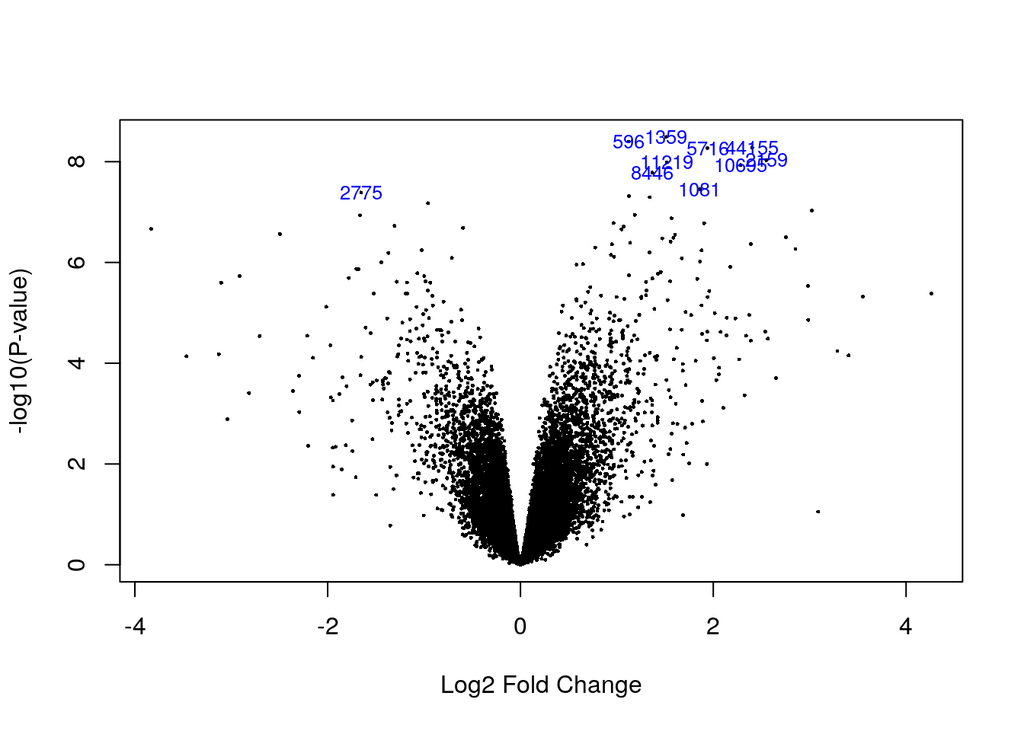

```r
volcanoplot(fit.main, coef="P_Chimp_B1", highlight=10)
```

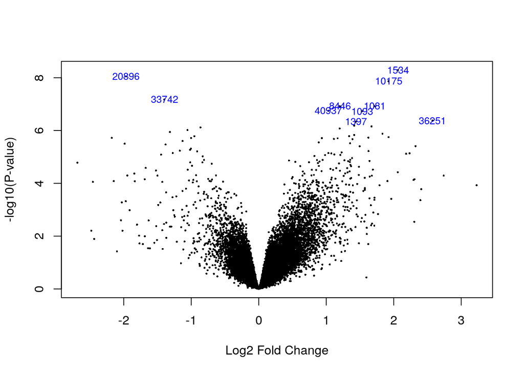

```r
volcanoplot(fit.main, coef="P_Chimp_B2", highlight=10)
```

Sergio Rodriguez Llana